# team

Jacob Baalson, Charlie Whiting; GitHub Usernames: jbaalson, chrlwhtng

2/5/2020

```r
choco <- read.csv("https://xdaiisu.github.io/ds202materials/hwlabs/choco.csv")
length(choco$Rating)
```

```
## [1] 1852
```

There are 1852 total chocolate bars that were rated in the data set.

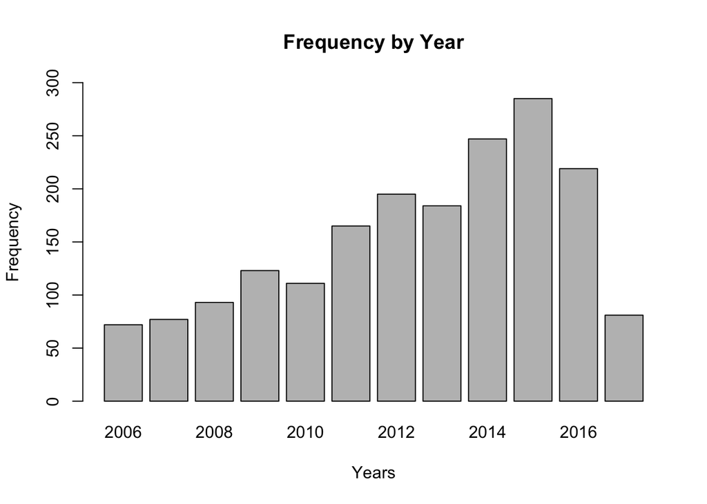

```r
barplot(table(choco$Review.Date), ylim = c(0,300), xlab = 'Years', ylab = 'Frequency', main= 'Frequency by Year')
```

```r
countryfrequency <- data.frame(table(choco$Company.Location))
countryfrequency[order(countryfrequency$Freq, decreasing = TRUE)[1:3], ]
```

```
##      Var1 Freq
## 58 U.S.A.  787
## 19 France  158
## 8  Canada  132
```

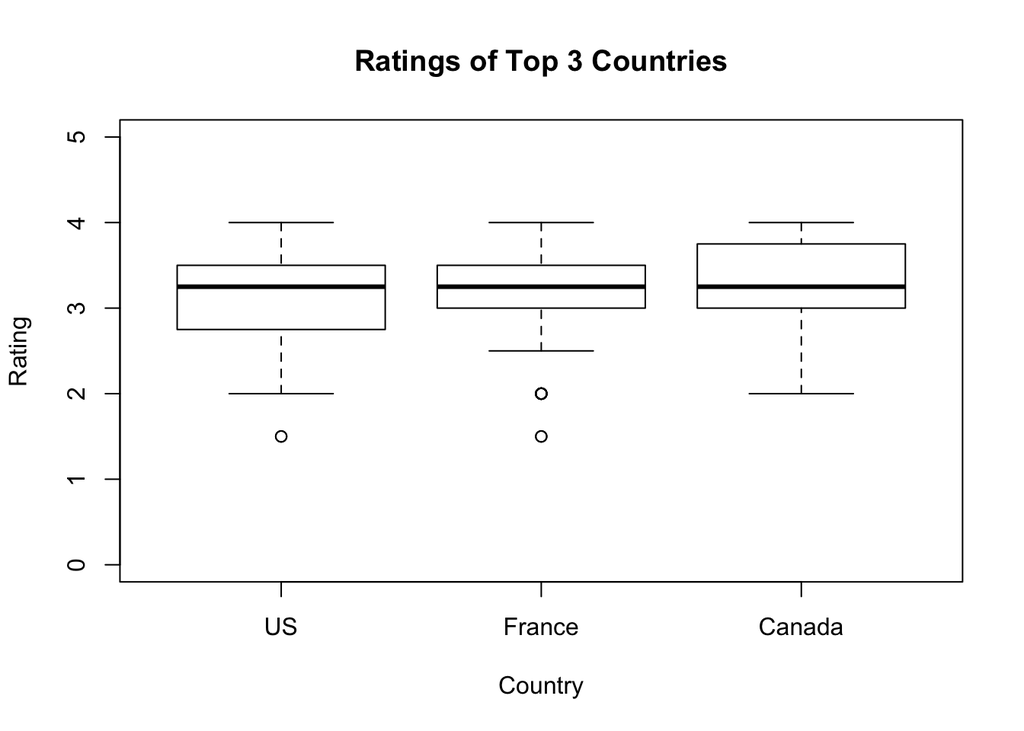

```r
US <- choco[choco$Company.Location == 'U.S.A.', ]
France <- choco[choco$Company.Location == 'France', ]
Canada <- choco[choco$Company.Location == 'Canada', ]
boxplot(US$Rating, France$Rating, Canada$Rating, ylim = c(0,5), names = c('US', 'France', 'Canada'), ylab = 'Rating', xlab = 'Country', main = 'Ratings of Top 3 Countries')
```

The U.S.A., France, and Canada have the most ratings. The “typical” rating for all of these countries is around 3.2. Canada does have the greatest Q3 with it being around 3.8 which is about 0.3 higher than the other countries Q3 marks. France has two outliers that are below the minimum whisker and the US has one outlier that is below the minimum whisker.

4. Question: Were certain years produce better chocolate ratings? Or were they largely the same?

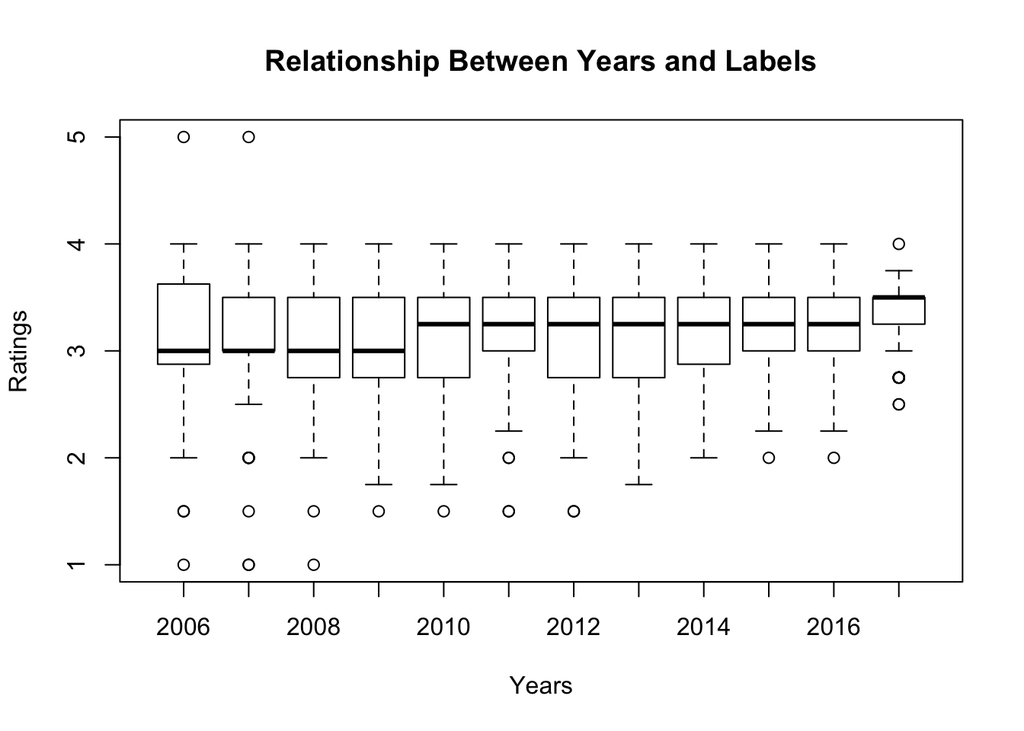

```r
chocoSix <- choco[choco$Review.Date == 2006, ]
chocoSeven <- choco[choco$Review.Date == 2007, ]
chocoEight <- choco[choco$Review.Date == 2008, ]
chocoNine <- choco[choco$Review.Date == 2009, ]
chocoTen <- choco[choco$Review.Date == 2010, ]
chocoEleven <- choco[choco$Review.Date == 2011, ]
chocoTwelve <- choco[choco$Review.Date == 2012, ]
chocoThirteen <- choco[choco$Review.Date == 2013, ]
chocoFourteen <- choco[choco$Review.Date == 2014, ]
chocoFifteen <- choco[choco$Review.Date == 2015, ]
chocoSixteen <- choco[choco$Review.Date == 2016, ]
chocoSeventeen <- choco[choco$Review.Date == 2017, ]

xlabels <- c(2006:2017)

boxplot(chocoSix$Rating, chocoSeven$Rating, chocoEight$Rating, chocoNine$Rating, chocoTen$Rating, chocoEleven$Rating, chocoTwelve$Rating, chocoThirteen$Rating, chocoFourteen$Rating, chocoFifteen$Rating, chocoSixteen$Rating, chocoSeventeen$Rating, names = xlabels, xlab = "Years", ylab = "Ratings", main = "Relationship Between Years and Labels")
```

6. The process of working with each other across different systems at the same time was very helpful. We very much liked having the ability to work together on our own devices. We switched off whose computer we worked on halfway through the “team” Markdown file. Because of this, we pushed an update to GitHub after finishing Question 3, and then again after completing Question 6. We didn’t struggle with much, because we were coordinated when we edited the files.